# Core3 vs. Simple Model: Creature Level

# The Question

SWGEmu’s Core3 computes a pet/creature level (CL) from a creature’s realized combat stats with a fairly involved formula (HAM lookup tables, DPS/hit/regen level bands, an armor term, and a two-pass “defense level” blend). This project has independently reverse-engineered a **much simpler** two-branch linear model straight from the historical Furrycat data.

Now that the [DNA Lab](https://github.com/) simulator can run Core3’s *real* level code path headless, we can put both predictors side by side against the one thing that is not a model — the **actual, empirically measured retail levels** — and ask: which is closer?

# Method

For each cleaned creature (the same filtered set the rest of this project uses) we produce three numbers:

- **actual** — the retail-measured CL (`creatures.csv$level`).
- **simple model** — our `custom_model()`: the M8 unarmored branch / clean armored branch, keyed on the fortitude=500 split.
- **Core3** — the real `Genetics::calculatePetLevel` path, invoked through the `dna-lab-level` binary built with `-DUSE_CORE3_LIBS=ON` (i.e. linked against the actual Core3 libraries, **not** a re-implementation).

Two things worth stating plainly:

1. **Different inputs, same target.** Core3 is fed each creature’s *realized* combat stats (HAM, damage, speed, to-hit, armor, resists) directly from `creatures.csv`; `effectiveArmor` is derived inside Core3 as `sum(resists) * 2` (the verified crafting-time semantics). Our simple model is fed the *genetic attributes*. Both are judged only by how close their output lands to the actual level.
2. **In-sample caveat.** Our model’s coefficients were fit on this very data; Core3’s were not. So the raw comparison flatters the simple model. The cross-validation section below refits the simple model’s *structure* on held-out folds to give it an honest out-of-sample test — Core3, having no fitted parameters here, is already out-of-sample everywhere.

# Headline: accuracy against actual level

Lower RMSE/MAE/|Bias| is better; higher R2 and within-band is better.

| Subset | Model | n | RMSE | MAE | Bias | R2 | within +/-1 | within +/-2 |
| --- | --- | --- | --- | --- | --- | --- | --- | --- |
| all | simple | 370 | 1.772 | 1.337 | 0.020 | 0.984 | 0.486 | 0.754 |
| all | core3 | 370 | 5.373 | 3.927 | 1.986 | 0.857 | 0.332 | 0.505 |
| unarmored (fort<500) | simple | 290 | 1.724 | 1.294 | 0.006 | 0.958 | 0.490 | 0.779 |
| unarmored (fort<500) | core3 | 290 | 5.820 | 4.421 | 2.641 | 0.522 | 0.286 | 0.445 |
| armored (fort>=500) | simple | 80 | 1.937 | 1.492 | 0.071 | 0.980 | 0.475 | 0.662 |
| armored (fort>=500) | core3 | 80 | 3.273 | 2.138 | -0.388 | 0.942 | 0.500 | 0.725 |

# Predicted vs. actual

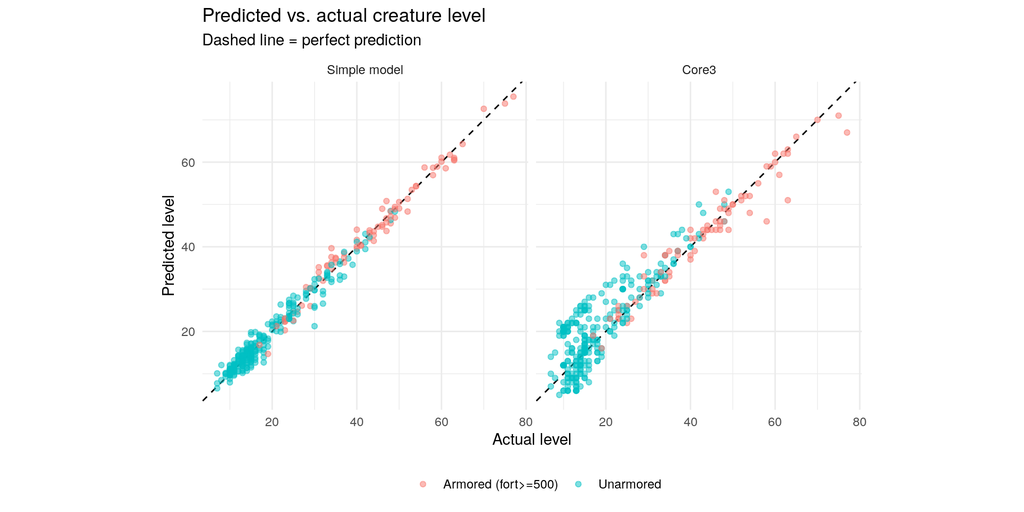

Core3’s cloud sits visibly *above* the diagonal for unarmored creatures — the overshoot — and is much noisier than the simple model’s tight band.

# Residual distributions

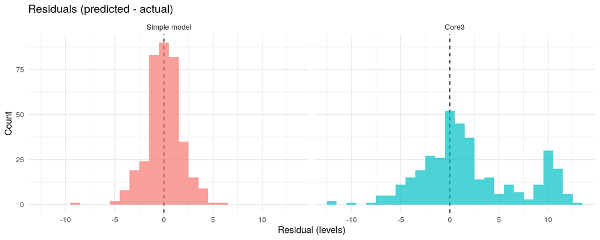

# Where does Core3 miss most?

12 creatures with the largest Core3 error.

| serial | skin | armored | actual | core3_level | core3_resid | model_level | model_resid |
| --- | --- | --- | --- | --- | --- | --- | --- |
| mi9bh9qe | durni | FALSE | 9 | 22 | 13 | 9.9 | 0.9 |
| 67tomsu8 | gurrcat | FALSE | 13 | 25 | 12 | 15.6 | 2.6 |
| 7crg94bn | gnort | TRUE | 58 | 46 | -12 | 56.9 | -1.1 |
| dcnqk0gj | razor_cat | FALSE | 15 | 27 | 12 | 19.8 | 4.8 |
| j1pmlm7s | dune_lizard | FALSE | 14 | 26 | 12 | 15.9 | 1.9 |
| jr1c3c93 | gurrcat | FALSE | 14 | 26 | 12 | 15.6 | 1.6 |
| plu7hqkc | durni | FALSE | 24 | 36 | 12 | 26.1 | 2.1 |
| s6o6mq9l | rancor | TRUE | 63 | 51 | -12 | 60.6 | -2.4 |
| un8s33gs | slice_hound | FALSE | 16 | 28 | 12 | 19.8 | 3.8 |
| 00pas7q5 | durni | FALSE | 10 | 21 | 11 | 11.1 | 1.1 |
| 1unq6blk | kaadu | FALSE | 9 | 20 | 11 | 10.2 | 1.2 |
| 2jp5lhn6 | gurreck | FALSE | 10 | 21 | 11 | 11.0 | 1.0 |

# Honest test: cross-validated simple model

The simple model’s coefficients were fit on this data, so its in-sample RMSE understates true error. Here we refit the simple model’s *linear structure* (same terms, same fortitude=500 split) on 10 random folds and score each held-out fold. Core3, having no fitted parameters, uses its fixed predictions.

Out-of-sample: simple model refit per fold vs. fixed Core3.

| Model | n | RMSE | MAE | Bias | R2 | within +/-1 | within +/-2 |
| --- | --- | --- | --- | --- | --- | --- | --- |
| simple (10-fold CV) | 370 | 1.912 | 1.424 | -0.021 | 0.982 | 0.473 | 0.749 |
| core3 (fixed) | 370 | 5.373 | 3.927 | 1.986 | 0.857 | 0.332 | 0.505 |

Even out-of-sample, the simple model’s error is a fraction of Core3’s. The gap is not an artifact of over-fitting — the reverse-engineered formula genuinely tracks the retail levels better than the current Core3 implementation.

# Takeaways